# HW03 Solutions

STATS401 team

9/17/2018

## Q2

### (a)

```r
# (a)
## download unemployment data file
download.file(destfile="unemployment.csv",
  url="https://ionides.github.io/401f18/01/unemployment.csv")

## read-in unemployment data into R
data <- read.table(file="unemployment.csv",sep=",",header=TRUE)
```

To define y, we look at a snipet of the dataset to see how to obtain ‘y’.

```
##   Year Jan Feb Mar Apr May Jun Jul Aug Sep Oct Nov Dec
## 1 1948 4.0 4.7 4.5 4.0 3.4 3.9 3.9 3.6 3.4 2.9 3.3 3.6
## 2 1949 5.0 5.8 5.6 5.4 5.7 6.4 7.0 6.3 5.9 6.1 5.7 6.0
## 3 1950 7.6 7.9 7.1 6.0 5.3 5.6 5.3 4.1 4.0 3.3 3.8 3.9
## 4 1951 4.4 4.2 3.8 3.2 2.9 3.4 3.3 2.9 3.0 2.8 3.2 2.9
## 5 1952 3.7 3.8 3.3 3.0 2.9 3.2 3.3 3.1 2.7 2.4 2.5 2.5
## 6 1953 3.4 3.2 2.9 2.8 2.5 2.7 2.7 2.4 2.6 2.5 3.2 4.2
```

As we can see, to define ‘y’, we need to take the average of all columns except the first one. This can be done in one of the following two ways:

```r
# (a) ctd
## Defining y
y <- apply(data[,-1],1,mean)
  #or
y <- apply(data[,2:ncol(data)],1,mean)
```

### (b)

Recall from class notes (Notes03,LM3 and Notes03, slide15) that the design matrix for such a model will be ${\mathbb{X}}=[\mathbf{x_1} \mathbf{x_2]}$ where $\mathbf{x_1}$ is the vector of years (that is, its $i^{th}$ entry corresponds to the $i^{th}$ year in the dataset) and $\mathbf{x_2}$ is a vector of 1s (of length equal to the number of observations in the dataset). Let us now construct this matrix

```r
#(b)
## Extract vector of years
x1 <- data$Year

## Define a vector containing 1s (of appropriate length)
x2 <- rep(1,nrow(data))

## Define X = [x1 x2]
X <- cbind(x1,x2)
```

### (c)

Recall formula for to obtain **b** from class notes (Notes03, LM4)

```r
# (c)
b <- solve(t(X)%*%X)%*%t(X)%*%y
rownames(b) <- c("b1","b2") #renaming the elements of b, this is not essential, being done here so that the notation                              matches that of the hw
b
```

```
##            [,1]
## b1   0.03134917
## b2 -56.29399009
```

### (d)

Here, we have to rename the first column ($\mathbf{x_1}$) as $\mathbf{x}$.

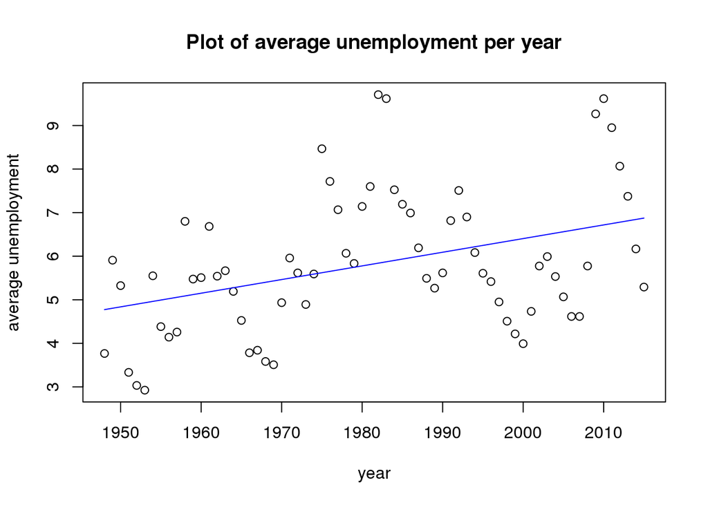

```r
# (d)
## Define x
x <- x1

## Define vector of fitted values
fitted_values <- c(X%*%b)

## Plot y ~ x
plot(x,y, main="Plot of average unemployment per year", ylab="average unemployment", xlab= "year")
lines(x,fitted_values,lty="solid",col="blue")
```

Clearly, there seems to be an increasing trend, that is, the average annual unemployment rate appears to be increasing every year.

### (e)

```r
# (e)
## Fitting the linear model
lm1 <- lm(y~x1, data = data) #remember x is labeled as x1 in the design matrix

## Compare first 5-values
lm1$fitted.values[1:5]
```

```
##        1        2        3        4        5
## 4.774190 4.805539 4.836888 4.868238 4.899587
```

```r
fitted_values[1:5]
```

```
## [1] 4.774190 4.805539 4.836888 4.868238 4.899587
```

```r
## Check if both vectors are equal by taking their difference
table(round(lm1$fitted.values - fitted_values,4))
```

```
##
##  0
## 68
```

## Q3

If ${\mathbb{A}},{\mathbb{B}}$ are two invertible square matrices, we have the property that ${\mathbb{(AB)}}^{-1} = {\mathbb{B}}^{-1}{\mathbb{A}}^{-1}$.  
However, this formula runs into difficulties if ${\mathbb{A}}$ or ${\mathbb{B}}$ is not invertible. This is the problem in the argument. In fact, ${\mathbb{X}}$ is usually not invertible. One way to see this is that ${\mathbb{X}}$ being invertible implies there is an exact solution to the system of equations ${\mathbb{X}}{\boldsymbol{\mathrm{b}}}={\boldsymbol{\mathrm{y}}}$ given by ${\boldsymbol{\mathrm{b}}}={\mathbb{X}}^{-1}{\boldsymbol{\mathrm{y}}}$. You may know that to determine $p$ variables in a system of linear equations, we need $p$ equations. Fewer than $p$ equations and we won’t have enough information to solve for $p$ variables. More than $p$ equations and likely there won’t be a solution. Thus, only a square matrix is invertible. For us, $n$ is the number of data points and $p$ is the number of coefficients in the linear model so usually $p$ is much less than $n$. Thus, ${\mathbb{X}}$ is not square and cannot be invertible.

If ${\mathbb{X}}$ were invertible then (a) would be true. The following steps (b), (c) and (d) are correct matrix calculations and so this product would in fact equal identity in that case.

## Q4

Since ${\mathbb{A}}$ is a square matrix whose determinant is $6 \neq 0$, its inverse exists. Now, we know that ${\mathbb{A}}{\mathbb{A}}^{-1} = {\mathbb{I}}$ where $mat{I}$ is a diagonal matrix as well. Also, from above we know that ${\mathbb{A}}{\mathbb{A}}^{-1}$ is the same as multiplying the first columns of ${\mathbb{A}}^{-1}$ by 1,2, and 3 respectively. Hence, the natural guess would be that
$${\mathbb{A}}^{-1} = \left[
\begin{array}{ccc}
1 & 0 & 0 \\
0 & 1/2 & 0 \\
0 & 0 & 1/3
\end{array}
\right].$$
and indeed this is correct! Let’s verify using R.

```r
# Q4
## Define A, inv_A
A <- matrix(c(1,0,0,0,2,0,0,0,3),3)
inv_A <- matrix(c(1,0,0,0,1/2,0,0,0,1/3),3)

## Verify
A%*%inv_A
```

```
##      [,1] [,2] [,3]
## [1,]    1    0    0
## [2,]    0    1    0
## [3,]    0    0    1
```